Estadística 1 | 2020

[figure not shown]

# Guía de Clase del TP3: Distribuciones de Probabilidad Discretas

Estadística 1 | 2020

Docentes: Patricia M. Acetta y Carlos A. Alesso

# Distribución de Probabilidades

En esta unidad integraremos algunos conceptos de estadística descriptiva y probabilidad vistos anteriormente para estudiar las variables aleatorias y sus distribuciones de probabilidades.

Una **variable aleatoria** (VA) es una variable (lo opuesto de constante) cuyos posibles valores ocurren de manera aleatoria de acuerdo a una distribución de probabilidad. Al igual que vimos anteriormentes, las varialbes ser **cualitativas** (valores no numericos o numéricos sin sentido numerico) o **cuantitativas** (numéricos). Dentro de este grupo diferenciamos aquellas **discretas** (VAD), cuando tiene un número finito de valores o un número de valores contable; o **continua** (VAC) si tiene un número infinito de valores, y esos valores pueden asociarse con mediciones en una escala continua, de manera que no existan huecos o interrupciones.

Cuando estudiamos una variable aleatoria, nos interesa conocer las probabilidades de ocurrencia de los posibles valores que puede tomar esta variable. Esto es la **distribución de probabilidades**. La distribución puede especificarse mediante el uso de tablas (similar a las tablas de frecuencias), gráficos (histogramas o gráficos de barras) o una función matemática o modelo.

A diferencia de la distribución de frecuencia que resume los valors que tomó una variable luego de un muestreo, la distribución de probabilidades expresa la probabilidad de ocurrencia que tiene cada valor, o conjunto de valores, de una variable aleatoria.

## Distribuciones de Probabilidad para Variables Aleatorias Discretas

Requisitos de una distribución de probabilidad:

- $\sum P(x_i) = 1$: donde $x_i$ asume todos los valores posibles. Es decir, la suma de todas las probabilidades debe ser 1.
- $0 \le P(x_i) \le 1$ para cada valor individual de $x_i$. Es decir, cada valor de probabilidad debe ubicarse entre 0 y 1, inclusive.

# Distribución Binomial

Puede usarse para el cálculo de probabilidades de eventos provenientes de conteos acotados o proporciones. Si $X$ es una VAD que registra el número de éxitos en una muestra tamaño $n$ y probabilidad $p$, su distribución de probabilidades es Binomial.

$$X \sim \text{Binom}(n, p)$$

**Supuestos**

- son experimentos aleatorios de tipo Bernoulli que se repiten $n$ veces, siendo $n$ un **número fijo y finito**
- en cada experimento se registra uno de dos resultados posibles, *éxito* ($x=1$) o *fracaso* ($x =0$)
- el éxito tiene una cierta probabilidad $p$ de ocurrencia y el fracaso $q = 1-p$.
- los experimentos son independientes, el resultado de un experimento no afecta al resultado de otro por lo tanto la probabilidad de éxito (o fracaso) se mantiene constante a través del conjunto de experimentos.
- interesa la variable aleatoria: número o cantidad de éxitos en los $n$ ensayos.

**Valor esperado**

La media o valor esperado de una variable aleatoria discreta es el resultado medio teórico de un número infinito de ensayos. Se denota por $E$ y, en el caso de VAD, representa el valor promedio de los resultados.

$$E(X) = \sum [xP(x)] = np$$

**Varianza**

La varianza de una variable aleatoria es el valor esperado de los desvíos cuadráticos de los valores de una variable respecto a su esperanza (media).

$$V(X) = npq$$

**Fórmulas de la Distribución Binomial**

Función de probabilidad $f(X)$ :

$$P(X = x) = {n \choose x} p^{x} q^{n-x}$$
Función de probabilidad acumulada $F(X)$:

$$P(X \le x_k) = \sum_{i = 0}^{x_k} {n \choose i} p^{i} q^{n-i}$$

**En R**

Utilizaremos la familia de funciones `*binom()`. Éstas son:

- `dbinom(x, size, prob)` devuelve la probabilidad para un determinado valor de $X$ o sea $P(X = x)$ (probabilidad en un **punto**)
- `pbinom(q, size, prob, lower.tail)` devuelve la probabilidad **acumulada** para un determinado valor de $X$ o sea $P(X \le x)$
- `qbinom(p, size, prob, lower.tail)` devuelve el **cuantil** de una distribución binomial para un determinado valor de probabilidad acumulada, es decir $P(X \le a) = p$
- `rbinom(n, size, prob)` devuelve $n$ números aleatorios de una distribución binomial con $p$ y muestra de tamaño `size`

Los argumentos:

- `x` es el *valor de la variable* $X$ cuya probabilidad se quiere averiguar
- `q` es el *valor de la variable* $X$ cuya probabilidad acumulada se quiere averiguar
- `p` es el valor de *probabilidad acumulada* cuyo cuantil se desea averiguar
- `size` es el tamaño de la muestra
- `prob` es la probabilidad de éxito
- `lower.tail` es para indicar en las distribuciones acumulada si lo que se desea es $P(X \le q)$, la probabilidad acumulada de todos los valores menores o iguales a `q`, `lower.tail = T` (por defecto), o bien $P(X > q)$, la probabilidad acumulada de todos los valores mayores a `q` (sin incluirlo), `lower.tail = F`.

**Importante!** Para cualquier número $x$

- $P(X \le x) = F(X = x)$
- $P(X < x) = P(X \le x-1) = F(X = x-1)$
- $P(X \ge x) = 1 - P(X < x) = 1 - F(X = x-1)$
- $P(X > x) = 1 - P(X \le x) = 1 - F(X = x)$

## Ejercicio 1

Un criadero de semillas afirma que el poder germinativo de las semillas de una nueva variedad de soja es del 85%.

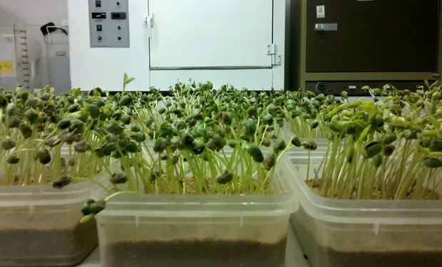

Un técnico decide probar éstas semillas, y para esto toma 200 semillas de la nueva variedad en forma aleatoria y las coloca en bandejas de germinación.

**Responder:**

1. ¿Cuál es la probabilidad de que de esas 200 semillas, germine el 85% de las semillas que indica el semillero?
2. ¿Cuál es la probabilidad de que al sembrar 500 semillas germinen el 80% o más de ellas?
3. ¿Cuál es la probabilidad de que si siembro las 500 semillas del item anterior, germinen menos 200 o menos semillas?
4. ¿Cuál es la probabilidad de que si siembro 1000 semillas, germinen al menos 800 y no más de 900 semillas?

## Item (a).

**¿Cuál es la probabilidad de que de esas 200 semillas, germine el 85% de las semillas que indica el semillero?**

Para responder ésta pregunta primero vamos a calcular cuantas semillas son el 85% de 200.

$$x = 0.85 \times 200 \text{ semillas} = 170 \text{ semillas}$$

*Luego, dado que queremos averiguar la probabilidad de $ x = 170$, es decir $P(X = 170) = P(170)$, vamos a utilizar la función `dbinom()` para calcular la probabilidad en el punto 170.*

**Paso 1:** definimos los parámetros de la distribución binomial:

```r
n <- 200   # 200 semillas sembradas
p <- 0.85  # 85% de probabilidad de que germinen
```

**Paso 2:** otros argumentos que necesitaremos para usar la función:

```r
x <- 200 * 0.85
```

**Paso 3:** Ingresamos todos los argumentos en la función:

```r
dbinom(x = x, size = n, prob = p)
```

```
## [1] 0.07877741
```

Nos indica un valor de 0.0787774.

Expresado en porcentaje:

*Respuesta:* 7.88% es la probabilidad de que si se siembran esas semillas germine el 85%.

## Item (b).

**¿Cuál es la probabilidad de que al sembrar 500 semillas germinen el 80% o más de ellas?**

El 80% de 500 semillas es: 400

```r
500*0.8
```

```
## [1] 400
```

$P(\text{germinen 400 semillas o más}) = P(X \ge 400)$

*Queremos incluir el número 400 y calcular la probabilidad acumulada de los valores mayores*

*Utilizaremos la función `pbinom()` para calcular probabilidades acumuladas*

Pasos:

**Paso 1:** definimos los parámetros de la distribución:

```r
p    # es la misma del item anterior
```

```
## [1] 0.85
```

```r
n <- 500     # 500 semillas en éste item
```

**Paso 2:** otros argumentos que necesitamos:

Queremos calcular los valores mayores a 400 semillas pero incluyendolo, entonces el valor de `q` va a ser 399 (no lo va a incluir si pongo `lower.tail` = F), calculará desde el 400 y mayores…

```r
q <- 399

pbinom(q = q, size = n, prob = p, lower.tail = F)
```

```
## [1] 0.9989565
```

Nos indica un valor de 0.9989565.

Expresado en porcentaje:

*Respuesta:* 99.9% es la probabilidad de que si siembro 500 de esas semillas germine el 80% o más de ellas.

## Item (c).

**¿Cuál es la probabilidad de que si siembro las 500 semillas del item anterior, germinen 200 o menos semillas?**

*Significa que queremos incluir al 200 y calcular la probabilidad acumulada de los valores inferiores*

*Utilizaremos la función `pbinom()` porque queremos calcular probabilidades acumuladas*

$P(x\le200)$

Pasos:

**Paso 1:** definimos los parámetros de la distribución:

```r
p    # es la misma del item anterior
```

```
## [1] 0.85
```

```r
n    # 500 semillas del item anterior
```

```
## [1] 500
```

**Paso 2:** otros argumentos que necesitamos:

`lower.tail`= T: ya que queremos calcular probabilidades menores al valor indicado en `q` (incluyendo el valor indicado)

`q` = 200

```r
q <- 200

pbinom(q = q, size = n, prob = p, lower.tail = T)
```

```
## [1] 2.944298e-117
```

Expresado en porcentaje:

*Respuesta:* 0% es la probabilidad de que si siembro 500 de esas semillas germinen 200 o menos semillas.

## Item (d).

**¿Cuál es la probabilidad de que si siembro 1000 semillas, germinen al menos 800 y no más de 900 semillas?**

*Queremos incluir al 800 y no al 900*

*Utilizaremos la función `pbinom()` porque queremos calcular probabilidades acumuladas entre 800 y 900 (sólo incluyendo al 800)*

Pasos:

**Paso 1:** definimos los parámetros de la distribución:

```r
p    # es la misma del item anterior
```

```
## [1] 0.85
```

```r
n <- 1000   # 1000 semillas
```

**Paso 2:** otros argumentos que necesitamos

```r
q1 <- 799
q2 <- 899
```

**Paso 3:** aplicación a la funcion `pbinom()`, podemos hacerlo de 2 maneras:

Alternativa 1: restando probabilidades acumuladas, calculandolas por separado

```r
P_799 <- pbinom(q = q1, size = n, prob = p)    # lower.tail = T, por defecto
P_899<- pbinom(q = q2, size = n, prob = p)

P_899 - P_799      # valor mayor - menor
```

```
## [1] 0.9999895
```

Alternativa 2: usando la función `diff()` para calcular diferencias (resta)

```r
diff(pbinom(q = c(q1, q2), size = n, prob = p))
```

```
## [1] 0.9999895
```

```r
# en el vector q = c(q1, q2), primero el valor menor y luego el mayor
```

Nos indica un valor de 0.9999895.

# Distribución Hipergeométrica

Esta distribución está ligada a situaciones de muestreo sin reposición, es decir situaciones en que al azar se elige un elemento de una población y así sucesivamente hasta completar la muestra, sin restituir los elementos extraídos.

Si $X$ es una VAD que registra el número de éxitos en una muestra de tamaño $n$ extraída **sin reposición** de una población $N$ con $N_1$ número de éxitos, su distribución de probabilidades es Hipergeométrica

$$X \sim \text{Hiper}(n, N, N_1)$$

$n$ es el tamaño de la muestra  
$N$ es el tamaño de la población  
$N_1$ es el número de éxitos

**Supuestos**

- son experimentos aleatorios de tipo Bernoulli **repetidos** $n$ veces
- $n$ es un **número fijo y finito**
- Cada experimento tiene **dos posibles resultados**: éxito (1) o fracaso (0)

**Valor esperado**

$$E(X) = n \cdot \dfrac{N_1}{N} = np$$

**Varianza**

$$V(X) = n \cdot \dfrac{N_1}{N} \cdot \dfrac{N-N_1}{N} \cdot \dfrac{N - n}{N - 1} = npq \dfrac{N - n}{N - 1}$$

**Fórmulas de la Distribución Hipergeométrica**

En **R**:

Las funciones de probabilidad hipergeométrica se obtienen con las funciones de la familia `*hyper()`

- `dhyper(x, m, n, k)` devuelve la probabilidad para un determinado valor de $X$ o sea $P(X = x)$
- `phyper(q, m, n, k, lower.tail)` devuelve la probabilidad acumulada para un determinado valor de $X$ o sea $P(X \le x)$
- `qhyper(p, m, n, k, lower.tail)` devuelve el cuantil de una distribución hipergeométrica para un determinado valor de probabilidad acumulada, es decir $P(X \le a) = p$
- `rhyper(nn, m, n, k)` devuelve `nn` números aleatorios de una distribución hypergeométrica

Los argumentos:

- `x` es el valor de la variable $X$ cuya probabilidad se quiere averiguar
- `q` es el valor de la variable $X$ cuya probabilidad acumulada se quiere averiguar
- `p` es el valor de probabilidad acumulada cuyo cuantil se desea averiguar
- `m` es el número de individuos con la caracteristica asociada al éxito
- `n` es el número de individuos con la caracteristica asociada al fracaso
- `k` es número de individuos extraídos de la población
- `lower.tail` es para indicar, en las distribuciones acumulada si lo que se desea es $P(X \le x)$ (por defecto `TRUE`) o $P(X > x)$ usando `lower.tail = F`

*Argumento `lower.tail`:*

- si es F: FALSE: significa que quiero calcular la probabilidad acumulada de todos los valores mayores a `q` (sin incluirlo)
- si es T: TRUE: significa que quiero calcular la probabilidad acumulada de todos los valores menores a `q` (incluyendolo)

**Importante!** Para cualquier número $x$

- $P(X \le x) = F(X = x)$
- $P(X < x) = P(X \le x-1) = F(X = x-1)$
- $P(X \ge x) = 1 - P(X < x) = 1 - F(X = x-1)$
- $P(X > x) = 1 - P(X \le x) = 1 - F(X = x)$

## Ejercicio 2

La mejor manera de provocar e incentivar el crecimiento natural de las plantas y cultivos es someterlos a altos niveles de temperatura, luminosidad y a una humedad relativa. Esto se consigue gracias a una **cámara de germinación**, donde se crea un clima idóneo que propicia la correcta evolución de las semillas plantadas en su interior.

[figure not shown]

Una empresa proveedora dispone de 120 cámaras de germinación, de las cuáles sólo 80 están bien calibradas.

**Responder:**

1. Si se toma una muestra aleatoria de 5 cámaras ¿Cuál es la probabilidad de que solamente 2 de las 5 estén bien calibradas?
2. Si se toma una muestra aleatoria de 10 cámaras ¿Cuál es la probabilidad de que menos 5 no estén calibradas?
3. Si se toma una muestra aleatoria de 10 cámaras ¿Cuál es la probabilidad de que más de 5 no estén calibradas?
4. ¿Cuántas cámaras se esperan que estén correctamente calibradas en una muestra de 50 cámaras?

## Item (a).

**Si se toma una muestra aleatoria de 5 cámaras ¿Cuál es la probabilidad de que solamente 2 de las 5 estén bien calibradas?**

*Queremos calcular la probabilidad en el punto:* $P(x=2)$

*Utilizaremos la funcion `dhyper()` porque queremos calcular la probabilidad en el punto 2.*

Pasos:

**Paso 1:** definimos los parámetros de la distribución hipergeometrica:

$n=5$ tamaño de la muestra $N = 120$ cámaras de germinación totales $N_1 = 80$ cámaras asociadas al éxito: bien calibradas (podría ser al revés, pero la pregunta hace referencia a las bien calibradas)

```r
n <- 5
N <- 120
N1 <-80
```

**Paso 2:** otros argumentos que necesitaremos para usar la función:

```r
x <- 2
```

**Paso 3:** Ingresamos todos los argumentos en la función:

```r
dhyper(x = x, m = N1, n = N - N1, k = n)
```

```
## [1] 0.1638216
```

Nos indica un valor de 0.1638216.

Expresado en porcentaje:

*Respuesta:* 16.38% es la probabilidad de que sólo 2 de las 5 cámaras seleccionadas estén calibradas.

## Item (b).

**Si se toma una muestra aleatoria de 10 cámaras ¿Cuál es la probabilidad de que menos 5 no estén calibradas?**

*En éste item cambia el éxito, ahora es las que no están calibradas*

*Queremos calcular la probabilidad acumulada:* $P(x<5)$

*No queremos incluir al 5*

*Utilizaremos la funcion `phyper()` porque queremos calcular la probabilidad acumulada*

Pasos:

**Paso 1:** definimos los parámetros de la distribución hipergeometrica:

$n=10$ tamaño de la muestra $N = 120$ cámaras de germinación totales $N_1 = 40$ cámaras no calibradas

```r
n <- 10
N <- 120
N1 <-40
```

**Paso 2:** otros argumentos que necesitaremos para usar la función:

Para definir `q`, tener en cuenta que no quiero incluir el valor 5 y que quiero calcular la probabilidad acumulada de los menores (`lower.tail = T`)

Cuando `lower.tail = T` incluye el valor de `q`, por lo tanto para que no tome el valor 5, se pone un valor inmediato menor, en éste caso, el valor 4

```r
q <- 4
```

**Paso 3:** Ingresamos todos los argumentos en la función:

```r
phyper(q = q, m = N1, n = N - N1, k = n)
```

```
## [1] 0.795924
```

```r
# lower.tail=T por defecto, no hace falta aclararlo
```

Nos indica un valor de 0.795924.

Expresado en porcentaje:

*Respuesta:* 79.59% es la probablidad de que de 10 cámaras seleccionadas, menos 5 no estén calibradas.

## Item (c).

**Si se toma una muestra aleatoria de 10 cámaras ¿Cuál es la probabilidad de que más de 5 no estén calibradas?**

*En éste item el éxito son las cámaras que no están calibradas*

*Queremos calcular la probabilidad acumulada:* $P(x>5)$

*No queremos incluir al 5*

*Utilizaremos la funcion `phyper()` porque queremos calcular la probabilidad acumulada*

Pasos:

**Paso 1:** definimos los parámetros de la distribución hipergeometrica:

$n=10$ tamaño de la muestra $N = 120$ cámaras de germinación totales $N_1 = 40$ cámaras no calibradas

```r
n <- 10
N <- 120
N1 <-40
```

**Paso 2:** otros argumentos que necesitaremos para usar la función:

Para definir `q`, tener en cuenta que no quiero incluir el valor 5 y que quiero calcular la probabilidad acumulada de los mayores (`lower.tail = F`)

Cuando `lower.tail = F` NO incluye el valor de `q`, por lo tanto si coloco el valor `q`=5, no lo incluirá.

```r
q <- 5
```

**Paso 3:** Ingresamos todos los argumentos en la función:

```r
phyper(q = q, m = N1, n = N - N1, k = n, lower.tail = F)
```

```
## [1] 0.06778948
```

Nos indica un valor de 0.0677895.

Expresado en porcentaje:

*Respuesta:* 6.78% es la probablidad de que de 10 cámaras seleccionadas, más de 5 no estén calibradas.

## Item (d).

**¿Cuántas cámaras se esperan que estén correctamente calibradas en una muestra de 50 cámaras?**

*La pregunta hace refencia al **valor esperado** o **esperanza***

Definimos los parámetros de la distribución hipergeometrica y aplicamos a la fórmula de la Esperanza de la distribución:

$n=50$ tamaño de la muestra $N = 120$ cámaras de germinación totales $N_1 = 80$ cámaras bien calibradas

```r
n <- 50
N <- 120
N1 <-80

Esperanza <- n * N1/N
Esperanza
```

```
## [1] 33.33333
```

```r
round(Esperanza, 0)    # redondeo a 0 decimales
```

```
## [1] 33
```

*Respuesta:* Se espera que estén correctamente calibradas 33 cámaras de germinación.

# Distribución Poisson

Si $X$ es una VAD que registra el número de éxitos $\lambda$ por unidad de tiempo o espacio, su distribución de probabilidades es Poisson

$$X \sim \text{Poiss}(\lambda)$$

**Supuestos**

- Experimentos aleatorios de tipo Bernoulli **distribuidos en el tiempo o espacio**
- Cada experimento tiene **dos posibles resultados**: éxito (1) o fracaso (0)
- $n$ es fijo y **infinito o muy grande** (el tiempo y espacio se puede dividir en infinitos intervalos)
- $p$ es **constante y pequeña**
- la cantidad de experimentos o repeticiones es infinito

**Funciones de probabilidad de la Distribución Poisson**

Función de probabilidad $f(X)$ :

$$P(X = x) = \dfrac{\lambda^x e^{-\lambda}}{x!}$$

Función de probabilidad acumulada $F(X)$:

$$P(X \le x) = \sum_{i = 0}^x \dfrac{\lambda^i e^{-\lambda}}{x!}$$

**Valor esperado**

$$E(X) = np = \lambda$$

**Varianza**

$$V(X) = np = \lambda$$

En **R**:

Las funciones de probabilidad poisson se obtienen con las funciones de la familia `*pois()`

- `dpois(x, lambda)` devuelve la probabilidad para un determinado valor de $X$ o sea $P(X = x)$
- `ppois(q, lambda, lower.tail)` devuelve la probabilidad acumulada para un determinado valor de $X$ o sea $P(X \le x)$
- `qpois(p, lambda, lower.tail)` devuelve el cuantil de una distribución de Poisson para un determinado valor de probabilidad acumulada, es decir $P(X \le a) = p$
- `rpois(n, lambda)` devuelve `n` numeros aleatorios tomados de una distribución Poisson con parámetro $\lambda$

Los argumentos:

- `x` es el valor de la variable $X$ cuya probabilidad se quiere averiguar
- `q` es el valor de la variable $X$ cuya probabilidad acumulada se quiere averiguar
- `p` es el valor de probabilidad acumulada cuyo cuantil se desea averiguar
- `lambda` es el número éxitos esperado o esperanza
- `lower.tail` es para indicar, en las distribuciones acumulada si lo que se desea es $P(X \le x)$ (por defecto `TRUE`) o $P(X > x)$ usando `lower.tail = F`

## Ejercicio 3

Un estudio de la Secretaría de Tránsito de la localidad de Puerto General San Martín, indica que el número promedio de camiones que llega por día al Puerto de Cargill es de 450.

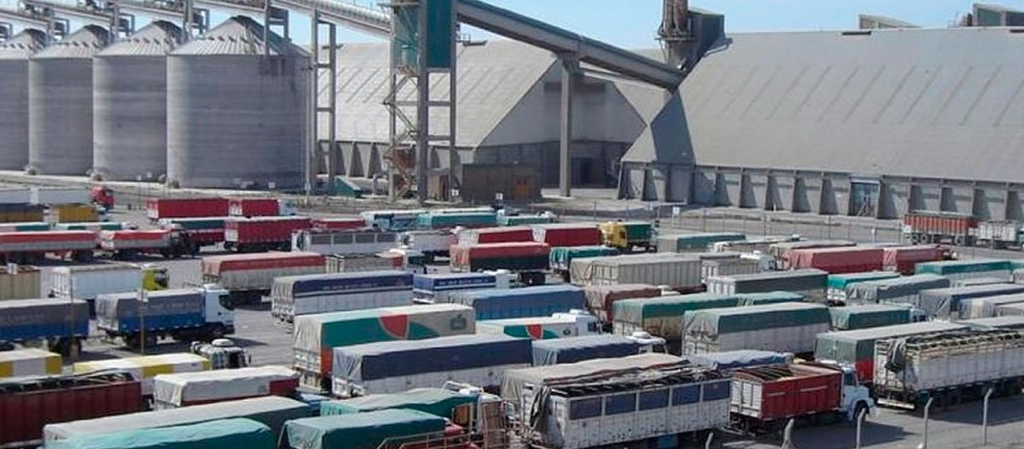

**Responder:**

1. ¿Cuál es la probabilidad de que en un día determinado lleguen más de 350 camiones?
2. ¿Cuál es la probabilidad de que en dos días lleguen 1000 o más camiones?
3. ¿Cuál es la probabilidad que en medio día lleguen entre más de 100 y menos de 200 camiones inclusive?
4. ¿Cuál es el valor esperado de camiones en una semana?

## Item (a).

**¿Cuál es la probabilidad de que en un día determinado lleguen más de 350 camiones?**

*Queremos calcular la probabilidad acumulada:* $P(x>350)$

*No incluimos el 350*

*Utilizaremos la funcion `ppois()` y el argumento `lower.tail = F` porque queremos calcular la probabilidad acumulada de los valores mayores a 350.*

Pasos:

**Paso 1:** definimos los parámetros de la distribución Poisson:

$\lambda=450 \text{ camiones por día}$

```r
lambda <- 450
```

**Paso 2:** otros argumentos que necesitaremos para usar la función:

*Si utilizo `lower.tail = F`, no incluye el valor que pongamos en `q`, en éste caso no queremos que incluya a 350*

```r
q <- 350
```

**Paso 3:** ingresamos todos los argumentos en la función:

```r
ppois(q = q, lambda = lambda, lower.tail = F)
```

```
## [1] 0.9999995
```

Nos indica un valor de 0.9999995.

Expresado en porcentaje:

*Respuesta:* 100% es la probabilidad de que lleguen más de 350 camiones en un día.

## Item (b).

**¿Cuál es la probabilidad de que en dos días lleguen 1000 o más camiones?**

*Queremos calcular la probabilidad acumulada:* $P(x\ge 1000)$

*Utilizaremos la funcion `ppois()` porque queremos calcular la probabilidad acumulada de los valores mayores o iguales a 1000*

Pasos:

**Paso 1:** definimos los parámetros de la distribución Poisson:

$\lambda=450 \text{ camiones por día} * \text{2 días} = 900$

```r
lambda <- 900
```

**Paso 2:** otros argumentos que necesitaremos para usar la función:

```r
q <- 1000
```

**Paso 3:** ingresamos todos los argumentos en la función:

```r
ppois(q = q, lambda = lambda, lower.tail = F)
```

```
## [1] 0.0004906327
```

Expresado en porcentaje:

## Item (c).

**¿Cuál es la probabilidad que en medio día lleguen entre más de 100 y menos de 200 camiones inclusive?**

*Queremos calcular la probabilidad acumulada entre dos valores:* $P(100< x\le 200)$

*Utilizaremos la funcion `ppois()` porque queremos calcular la probabilidad acumulada*

Pasos:

**Paso 1:** definimos los parámetros de la distribución Poisson:

$\lambda=450 \text{ camiones por día} / 2 = 225$

*Lambda se divide por dos porque la pregunta es por medio día*

```r
lambda <- 450/2
```

**Paso 2:** otros argumentos que necesitaremos para usar la función:

```r
q1 <- 101
q2 <-200
```

**Paso 3:** ingresamos todos los argumentos en la función, podemos hacerlo de 2 maneras:

Alternativa 1: restando probabilidades acumuladas, calculandolas por separado

```r
P_101 <- ppois(q = q1, lambda = lambda)    # lower.tail = T, por defecto
P_200<- ppois(q = q2, lambda = lambda)

P_200 - P_101           # valor mayor - menor
```

```
## [1] 0.04915755
```

Alternativa 2: usando la función `diff()` para calcular diferencias (resta)

```r
diff(ppois(q = c(q1, q2), lambda = lambda))
```

```
## [1] 0.04915755
```

```r
# en el vector q = c(q1, q2), primero el valor menor y luego el mayor
```

Nos indica un valor de 0.0491575.

Expresado en porcentaje:

## Item (d).

**¿Cuál es el valor esperado de camiones que llegarán al Puerto de Cargill en una semana?**

$\lambda=450 \text{ camiones por día}$ * 7 días en una semana

```r
450*7
```

```
## [1] 3150
```

*Respuesta:* El número de camiones que se esperan recibir en una semana es de 3150 en el Puerto de Cargill.

Material preparado por [Cátedra de Estadística FCA-UNL](https://github.com/estadistica-fcaunl/)

[figure not shown]